# NGS2017 Differential ChIP-seq Workshop

In this R notebook we will go through a typical differential ChIP-seq analysis workflow starting from indexed bam files and using R BioConductor package `csaw`

### Project setup

We will use R package `projectTemplate` to easily set up and manage directory structure, libraries, etc

```r
## Check that the required packages are installed. If not, install them.
if(!("csaw" %in% installed.packages())) {source("http://bioconductor.org/biocLite.R"); biocLite("csaw")}
if(!("GenomicRanges" %in% installed.packages())) {source("http://bioconductor.org/biocLite.R"); biocLite("GenomicRanges")}
if(!("GenomicAlignments" %in% installed.packages())) {source("http://bioconductor.org/biocLite.R"); biocLite("GenomicAlignments")}
if(!("GenomicFeatures" %in% installed.packages())) {source("http://bioconductor.org/biocLite.R"); biocLite("GenomicFeatures")}
if(!("edgeR" %in% installed.packages())) {source("http://bioconductor.org/biocLite.R"); biocLite("edgeR")}
if(!("TxDb.Mmusculus.UCSC.mm10.knownGene" %in% installed.packages())) {source("http://bioconductor.org/biocLite.R"); biocLite("TxDb.Mmusculus.UCSC.mm10.knownGene")}
if(!("org.Mm.eg.db" %in% installed.packages())) {source("http://bioconductor.org/biocLite.R"); biocLite("org.Mm.eg.db")}
if(!("ProjectTemplate" %in% installed.packages())) {install.packages("ProjectTemplate")}
## Create the directory structure
library(ProjectTemplate)
if (!dir.exists("config")) {
    create.project(getwd(), merge.strategy = "allow.non.conflict")
}
## Set the path to data directory
data.path <- "~/Downloads/bam.files/analysis/differential.ChIP-seq.data"
## Soft link to data directory
system(paste0("ln -s ", data.path, "/* ./data"))
## Copy project configuration file
system("cp global.dcf ./config")
## Load the project
load.project()
```

```
Loading project configuration
Autoloading packages
 Loading package: GenomicRanges
 Loading package: csaw
 Loading package: edgeR
 Loading package: GenomicFeatures
 Loading package: TxDb.Mmusculus.UCSC.mm10.knownGene
 Loading package: org.Mm.eg.db
 Loading package: GenomicAlignments
Autoloading helper functions
 Running helper script: helpers.R
```

# Step 1: Counting reads into windows

### Check mapping stats

```r
## Set the path to bam files
path.to.bams <- "./data/bams/"
## Get bam file names
bam.files <- list.files(path.to.bams, ".bam$", recursive = T, full.names = T)
print(bam.files)
```

```
[1] "./data/bams//ENCFF540HFT.bam" "./data/bams//ENCFF562SMG.bam"
[3] "./data/bams//ENCFF686DEV.bam" "./data/bams//ENCFF815MRR.bam"
[5] "./data/bams//ENCFF846DLR.bam" "./data/bams//ENCFF851MHM.bam"
[7] "./data/bams//ENCFF874RFY.bam" "./data/bams//ENCFF911ZQM.bam"
```

```r
## Extract sample names from bam files
snames <- gsub(".bam", "", basename(bam.files))
print(snames)
```

```
[1] "ENCFF540HFT" "ENCFF562SMG" "ENCFF686DEV" "ENCFF815MRR" "ENCFF846DLR"
[6] "ENCFF851MHM" "ENCFF874RFY" "ENCFF911ZQM"
```

```r
## Calculate and report mapping stats
if (file.exists("./cache/diag.stats.rds")) {
    diag.stats <- readRDS("./cache/diag.stats.rds")
} else {
    diagnostics <- list()
    for (bam in bam.files) {
        total <- countBam(bam)$records
        mapped <- countBam(bam, param=ScanBamParam(
            flag=scanBamFlag(isUnmapped=FALSE)))$records
        marked <- countBam(bam, param=ScanBamParam(
            flag=scanBamFlag(isUnmapped=FALSE, isDuplicate=TRUE)))$records
        diagnostics[[bam]] <- c(Total=total, Mapped=mapped, Marked=marked)
    }
    diag.stats <- data.frame(do.call(rbind, diagnostics))
    diag.stats$Prop.mapped <- round(diag.stats$Mapped/diag.stats$Total*100, 2)
    diag.stats$Prop.marked <- round(diag.stats$Marked/diag.stats$Mapped*100, 2)
    diag.stats$Total.pairs <- diag.stats$Total / 2
    diag.stats$Mapped.pairs <- diag.stats$Mapped / 2
    diag.stats$library.size <- diag.stats$Mapped.pairs * (1 - diag.stats$Prop.marked/100)
    rownames(diag.stats) <- basename(rownames(diag.stats))
    saveRDS(diag.stats, "./cache/diag.stats.rds")
}
print(diag.stats)
```

|  | Total | Mapped | Marked | Prop.mapped | Prop.marked | Total.pairs | Mapped.pairs | library.size |
| --- | --- | --- | --- | --- | --- | --- | --- | --- |
| ENCFF540HFT.bam | 558986 | 558986 | 0 | 100 | 0 | 279493.0 | 279493.0 | 279493.0 |
| ENCFF562SMG.bam | 589814 | 589814 | 0 | 100 | 0 | 294907.0 | 294907.0 | 294907.0 |
| ENCFF686DEV.bam | 1309278 | 1309278 | 0 | 100 | 0 | 654639.0 | 654639.0 | 654639.0 |
| ENCFF815MRR.bam | 666225 | 666225 | 0 | 100 | 0 | 333112.5 | 333112.5 | 333112.5 |
| ENCFF846DLR.bam | 1430950 | 1430950 | 0 | 100 | 0 | 715475.0 | 715475.0 | 715475.0 |
| ENCFF851MHM.bam | 644141 | 644141 | 0 | 100 | 0 | 322070.5 | 322070.5 | 322070.5 |
| ENCFF874RFY.bam | 1284978 | 1284978 | 0 | 100 | 0 | 642489.0 | 642489.0 | 642489.0 |
| ENCFF911ZQM.bam | 1484679 | 1484679 | 0 | 100 | 0 | 742339.5 | 742339.5 | 742339.5 |

### Determine parameters for counting the reads.

First we’ll try to estimate read fragment from read cross-correlation

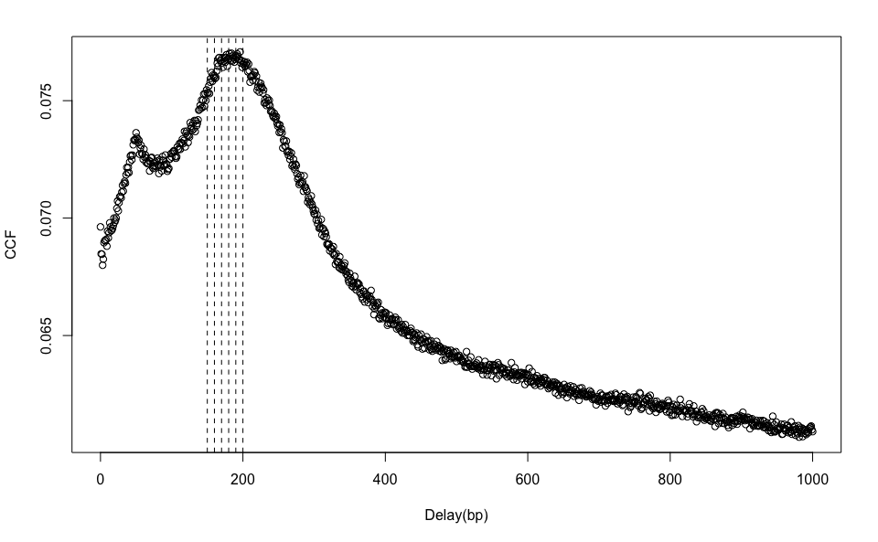

```r
## Generate the cross-correlation plot to determine fragment size
if (file.exists("./cache/correlated.reads.rds")) {
    correlated.reads <- readRDS("./cache/correlated.reads.rds")
} else {
    dedup.on <- readParam(dedup=TRUE, minq=30, restrict=paste0("chr", c(1:19, "X", "Y")))
    max.delay <- 1000
    correlated.reads <- correlateReads(bam.files, max.delay, param=dedup.on)
    saveRDS(correlated.reads, "./cache/correlated.reads.rds")
}
plot(0:max.delay,  correlated.reads, ylab="CCF", xlab="Delay(bp)")
abline(v = seq(150, 200, 10), lty=2)
```

From the cross-correlation plot it appears that the most abundant fragment length is around 180 bp. So we’ll set the fragment length accordingly. Now let’s look at the average peak size.

```r
if (file.exists("./cache/peak.size.rds")) {
    collected <- readRDS("./cache/peak.size.rds")
} else {
    collected <- list()
    for (curbam in bam.files) {
        windowed <- windowCounts(curbam, spacing=50, width=50, param=dedup.on)
        rwsms <- rowSums(assay(windowed))
        maxed <- findMaxima(rowRanges(windowed), range=1000, metric=rwsms)
        collected[[curbam]] <- profileSites(curbam, rowRanges(windowed)[maxed], param=dedup.on, weight=1/rwsms[maxed])
    }
    saveRDS(collected, "./cache/peak.size.rds")
}
clrs <- rep(c("dodgerblue", "forestgreen", "maroon", "yellow", "orange", "darkred", "darkgrey", "black"), 3)
xranged <- as.integer(names(collected[[1]]))
plot(xranged, collected[[1]], type="l", col = clrs[1], xlim=c(-1000, 1000), lwd=2, xlab="Distance (bp)", ylab="Relative coverage per base", ylim = c(0, 1), xaxt = "n", main = "Coverage plot")
for (i in 2:length(collected)) {
    lines(xranged, collected[[i]], col = clrs[i], lwd = 2)
}
```

```r
legend("topright", fill = clrs[1:length(bam.files)], snames)
abline(v=seq(-500, 500, 50), col="dodgerblue", lty=2)
```

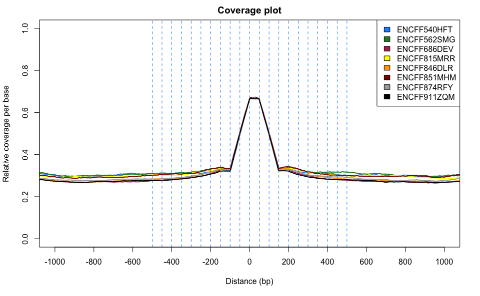

```r
axis(1, at = seq(-1000, 1000, 200), labels = seq(-1000, 1000, 200))
```

It looks like most of coverage falls between -150 and 150 bp. So we’ll set the window width to 300 bp and shift the windows by half the window width.

Let’s set up counting parameters

```r
## Load the ENCODE blacklisted regions
ENCODE.blacklist.mm10 <- readRDS("./data/ENCODE.blacklist.mm10.rds")
## The length to which each read should be extended
frag.len = 180
## The size of the window
window.width = 300
## The step of the window
spacing = window.width/2
## The minimum number of reads across all samples in a given window to keep that window
fltr = 10
dedup.on <- readParam(dedup=TRUE, # ignore reads marked as duplicates
                      minq=30, # ignore reads with mapping quality below 50
                      discard = ENCODE.blacklist.mm10, # Discard reads falling into regions blacklisted by ENCODE
                      restrict=paste0("chr", c(1:19, "X", "Y")), # restrict analysis to consensus chromosomes
                      pe = "none") # treat the reads as single end
```

### Count reads into pre-determined regions

Now we are all set to count the reads into windows.

```r
if (!file.exists(paste0("./cache/", "windowed.", window.width, "bp.counts.rds"))) {
    windowed.counts <- windowCounts(bam.files, ext=frag.len, width=window.width, spacing = spacing, param = dedup.on, filter = fltr)
    saveRDS(windowed.counts, file=paste0("./cache/", "windowed.", window.width, "bp.counts.rds"))
}
```

We will also count the reads into large bins (20 kb) which could be used to account for particular biases. We won’t really use them for this dataset.

```r
if (!file.exists(paste0("./cache/", "binned.20kb.counts.rds"))) {
    binned.counts <- windowCounts(bam.files, bin=TRUE, width=20000L, param = dedup.on, filter = fltr)
    saveRDS(binned.counts, file=paste0("./cache/", "binned.20kb.counts.rds"))
}
```

## Differential binding analysis

```r
## Set the significance cut offs
window.pval.cut.off <- 0.01
fdr.cut.off <- 0.05
windowed.counts <- readRDS(paste0("./cache/", "windowed.", window.width, "bp.counts.rds"))
large.bin.counts <- readRDS(paste0("./cache/", "binned.20kb.counts.rds"))
## Check file order in count objects
if(!all(windowed.counts$bam.files ==  large.bin.counts$bam.files)) {
    stop("The file order in the count objects is not the same")
}
## Build the filenames
experim.param <- read.csv("./data/mouse.encode.download.csv", stringsAsFactors = F)
experim.param <- experim.param[match(basename(windowed.counts$bam.files), basename(experim.param$File.download.URL)),]
print(experim.param)
```

|  | File.accession | File.format | Output.type | Experiment.accession | Assay | Biosample.term.id | Biosample.term.name | Biosample.type | Biosample.life.stage | Biosample.sex | Biosample.Age | Biosample.organism | Biosample.treatments | Biosample.subcellular.fraction.term.name | Biosample.phase | Biosample.synchronization.stage | Experiment.target | Antibody.accession | Library.made.from | Library.depleted.in | Library.extraction.method | Library.lysis.method | Library.crosslinking.method | Library.strand.specific | Experiment.date.released | Project | RBNS.protein.concentration | Library.fragmentation.method | Library.size.range | … |
| --- | --- | --- | --- | --- | --- | --- | --- | --- | --- | --- | --- | --- | --- | --- | --- | --- | --- | --- | --- | --- | --- | --- | --- | --- | --- | --- | --- | --- | --- | --- |
| 5 | ENCFF540HFT | bam | alignments | ENCSR066XXZ | ChIP-seq | UBERON:0002028 | hindbrain | tissue | embryonic | mixed | 14.5 day | Mus musculus | NA | NA | NA | NA | H3K36me3-mouse | ENCAB000ADV | DNA | NA | NA | SDS | NA | FALSE | 29/06/10 | ENCODE | NA | NA | NA | … |
| 6 | ENCFF562SMG | bam | alignments | ENCSR066XXZ | ChIP-seq | UBERON:0002028 | hindbrain | tissue | embryonic | mixed | 14.5 day | Mus musculus | NA | NA | NA | NA | H3K36me3-mouse | ENCAB000ADV | DNA | NA | NA | SDS | NA | FALSE | 29/06/10 | ENCODE | NA | NA | NA | … |
| 4 | ENCFF686DEV | bam | alignments | ENCSR087JEN | ChIP-seq | UBERON:0001890 | forebrain | tissue | embryonic | mixed | 13.5 day | Mus musculus | NA | NA | NA | NA | H3K36me3-mouse | ENCAB910BYC | DNA | NA | NA | SDS | NA | FALSE | 22/06/11 | ENCODE | NA | NA | NA | … |
| 7 | ENCFF815MRR | bam | alignments | ENCSR227UTY | ChIP-seq | UBERON:0001890 | forebrain | tissue | embryonic | mixed | 14.5 day | Mus musculus | NA | NA | NA | NA | H3K36me3-mouse | ENCAB000ADV | DNA | NA | NA | SDS | NA | FALSE | 29/06/10 | ENCODE | NA | NA | NA | … |
| 1 | ENCFF846DLR | bam | alignments | ENCSR972MUO | ChIP-seq | UBERON:0002028 | hindbrain | tissue | embryonic | mixed | 13.5 day | Mus musculus | NA | NA | NA | NA | H3K36me3-mouse | ENCAB910BYC | DNA | NA | NA | SDS | NA | FALSE | 22/06/11 | ENCODE | NA | NA | NA | … |
| 8 | ENCFF851MHM | bam | alignments | ENCSR227UTY | ChIP-seq | UBERON:0001890 | forebrain | tissue | embryonic | mixed | 14.5 day | Mus musculus | NA | NA | NA | NA | H3K36me3-mouse | ENCAB000ADV | DNA | NA | NA | SDS | NA | FALSE | 29/06/10 | ENCODE | NA | NA | NA | … |
| 3 | ENCFF874RFY | bam | alignments | ENCSR087JEN | ChIP-seq | UBERON:0001890 | forebrain | tissue | embryonic | mixed | 13.5 day | Mus musculus | NA | NA | NA | NA | H3K36me3-mouse | ENCAB910BYC | DNA | NA | NA | SDS | NA | FALSE | 22/06/11 | ENCODE | NA | NA | NA | … |
| 2 | ENCFF911ZQM | bam | alignments | ENCSR972MUO | ChIP-seq | UBERON:0002028 | hindbrain | tissue | embryonic | mixed | 13.5 day | Mus musculus | NA | NA | NA | NA | H3K36me3-mouse | ENCAB910BYC | DNA | NA | NA | SDS | NA | FALSE | 22/06/11 | ENCODE | NA | NA | NA | … |

```r
snames <- gsub(" ", ".", paste(experim.param$Biosample.term.name, experim.param$Biosample.Age))
groups <- as.factor(gsub("(.*).1.*", "\\1", snames))
snames <- paste(snames, 1:length(snames), sep = ".")
```

### Exploratory analyses

#### Plot library sizes.

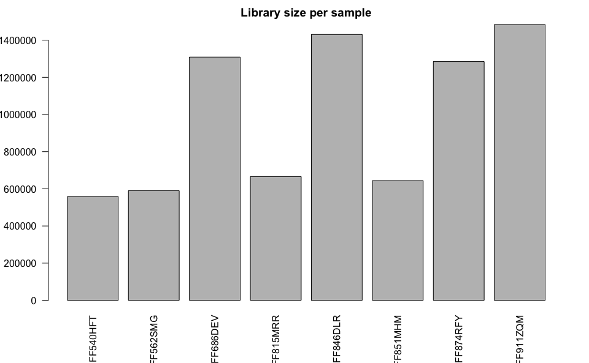

```r
snames <- gsub(".bam", "", (basename(windowed.counts$bam.files)))
barplot(windowed.counts$totals, names.arg = snames, las = 2, main = "Library size per sample")
```

#### Visualise abundance cut off

```r
## Set the abundance cut off
abundance.cut.off <- 4.5
## Calculate average abundance for all the windows for filtering
abundances <- aveLogCPM(asDGEList(windowed.counts))
keep <- abundances > abundance.cut.off
summary(keep)
```

```
   Mode   FALSE    TRUE    NA's
logical  336056   26742       0
```

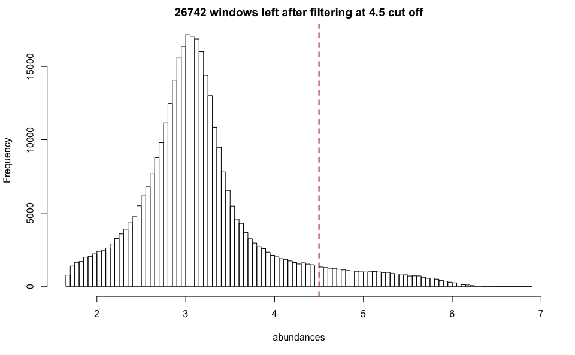

```r
## Plot distribution of average abundances
hist(abundances, breaks = 100, main = paste0(sum(keep), " windows left after filtering at ", abundance.cut.off, " cut off"))
abline(v = abundance.cut.off, lty = 2, col = "maroon", lwd = 2)
```

```r
## Make a new object only containing the filtered windows
filtered.counts <- windowed.counts[keep ,]
## Calculate normalisation factors for different types of biases
normfacs.comp <- normOffsets(large.bin.counts)
normfacs.eff <- normOffsets(filtered.counts)
```

#### Visualise relationships between individual samples and the effect of normalisation

We will plot an MA plot of the first sample against every other sample. We will also draw horisontal lines where y=0 would be if we were to apply specific scaling normalisations.

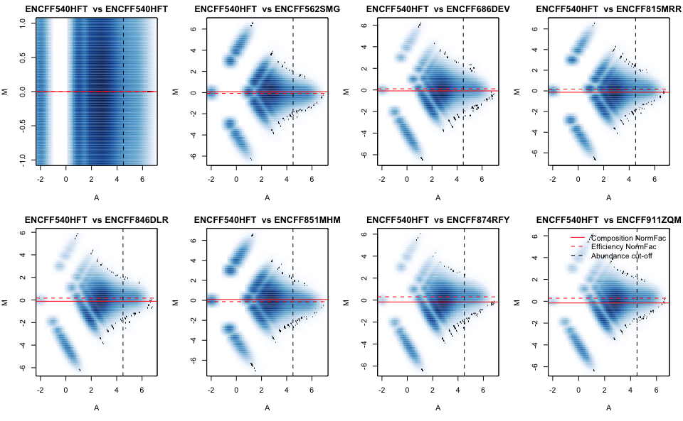

```r
## Calculate cpm values for each sample (all windows included)
adj.counts <- cpm(asDGEList(windowed.counts), log=TRUE)
k <- 1 # Set the sample to serve as a reference
par(mfrow=c(2, ncol(filtered.counts)/2) , mar=c(5,4,2,1.5))
for (i in 1:(length(filtered.counts$bam.files))) {
    cur.x <- adj.counts[,k]
    cur.y <- adj.counts[,i]
    smoothScatter(x=(cur.x+cur.y)/2, y=cur.x-cur.y, xlab="A", ylab="M", main=paste(snames[k], " vs", snames[i]))
    all.dist <- diff(log2(normfacs.comp[c(i, k)]))
    abline(h=all.dist, col="red")
    all.dist <- diff(log2(normfacs.eff[c(i, k)]))
    abline(h=all.dist, col="red", lty = 2)
    abline(v = abundance.cut.off, lty = 2)
}
legend("topright", legend = c("Composition NormFac", "Efficiency NormFac", "Abundance cut-off"), lty = c(1, 2, 2), col = c(2, 2, 1), bty = "n")
```

#### Plot an MDS plot of the sampels

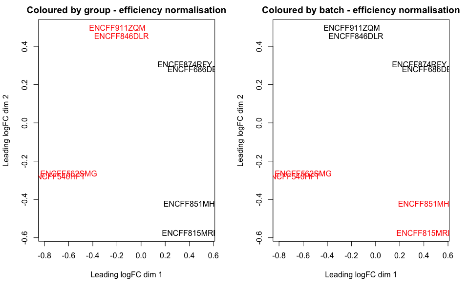

```r
## Convert counts into a DGEList
x <- asDGEList(filtered.counts)
## Set normalisation scaling factors to the computed efficiency normalisation factors
x$samples$norm.factors <- normfacs.eff
## Annotate the samples
x$samples$group <- groups
x$samples$batch <- as.factor(gsub(" ", "", experim.param$Biosample.Age))
rownames(x$samples) <- snames
colnames(x$counts) <- rownames(x$samples)
## Plot an MDS plot
par(mfrow=c(1,2))
plotMDS(cpm(x, normalized.lib.sizes = T, prior.count = 0.5, log = T), col = as.numeric(x$samples$group), main = "Coloured by group - efficiency normalisation", top = 1000)
plotMDS(cpm(x, normalized.lib.sizes = T, prior.count = 0.5, log = T), col = as.numeric(x$samples$batch), main = "Coloured by batch - efficiency normalisation", top = 1000)
```

From the MDS plot we can see that there is a strong batch effect, as samples are separated according to batch along the 2nd dimension.

### Differential binding analysis

```r
## Set up the design matrix
des <- model.matrix(~ 0 + x$samples$group)
colnames(des) <- levels(x$samples$group)
x <- estimateDisp(x, design = des)
## Make variance vs abundance plots
par(mfrow=c(1,2))
plotBCV(x)
## Fit a model
fit <- glmQLFit(x, des, robust=TRUE)
plotQLDisp(fit)
```

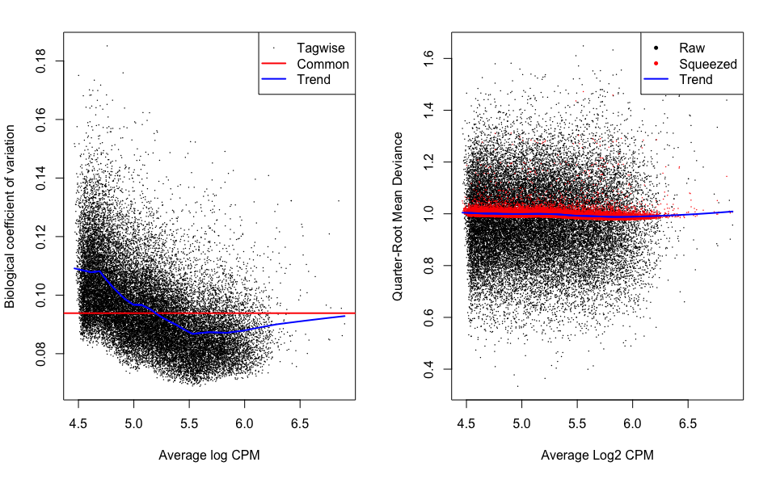

```r
## Set up the contrast of interest
ForeVsHind <- makeContrasts(forebrain - hindbrain, levels = des)
## Run quasi-likelihood F test
results <- glmQLFTest(fit, contrast = ForeVsHind)
sum.table <- as.data.frame(rbind(
    window.level.pVal.lt.0.01 = c(
        "total.count" = nrow(results$table),
        "all.DB" = sum(results$table$PValue < window.pval.cut.off),
        "DB.Up" = sum(results$table$PValue < window.pval.cut.off  & results$table$logFC > 0),
        "DB.Down" = sum(results$table$PValue < window.pval.cut.off  & results$table$logFC < 0))))
## Draw the MA plot for individual windows
par(mfrow=c(1,1))
```

```r
smoothScatter(results$table$logCPM, results$table$logFC, main = paste0(sum.table$DB.Up, " up, ", sum.table$DB.Down, " down\nat uncorrected pVal=", window.pval.cut.off))
abline(h=0, lty = 2, lwd = 2)
```

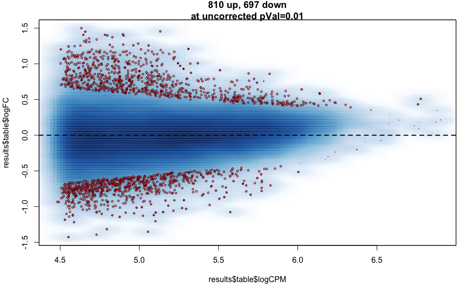

```r
points(results$table$logCPM[results$table$PValue <= window.pval.cut.off], results$table$logFC[results$table$PValue < window.pval.cut.off], col="darkred", cex=0.5)
```

It’s not very striking, but it looks like there is a trended bias in the above MA plot, i.e. higher abundance windows tend to shift slightly towards one of the conditions. Another way of looking at it, DB windows with average logCPM > 6 are mostly up-regulated. We will try to correct for that bias later. But first, to finish with this “first pass” analysis, let’s cluster adjacent windows and see how many differentially bound clusters we get after correcting for multiple testing. Combining the test for the windows within the same cluster does not take direction into account. I.e. we could have some depleted and some enriched windows in the same cluster and as long as some (or all of them) are significant, the combined p value will likely be significant too. So to “assign” a direction to the cluster, we will take the window with the lowest p value and use it to describe the entire cluster, i.e. the direction of change.

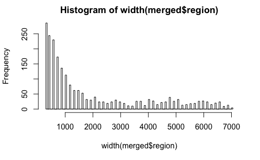

```r
## Cluster overlapping and adjacent windows into clusters (if two windows are more than window apart - don't merge them). Use maximum cluster size set in the parameters file. If a cluster is larger than the maximum size, it is split into 2 equal clusters.
## Set the maximum cluster size
max.cluster.size <- 7000L
merged <- mergeWindows(rowRanges(filtered.counts), tol = 1L, max.width = max.cluster.size)
## Plot size distribution of clustered windows
hist(width(merged$region), breaks = 100)
```

```r
## Combine p values of the clustered windows
tabcom <- combineTests(merged$id, results$table)
## Add the "best window" info for each cluster. "Best window" is defined as the window with the smallest p value in a given cluster.
tab.best <- getBestTest(merged$id, results$table)
colnames(tab.best) <- paste0("window.", colnames(tab.best))
tabcom <- cbind(tabcom, tab.best)
print(head(tabcom[order(tabcom$PValue),]))
```

|  | nWindows | logFC.up | logFC.down | PValue | FDR | window.best | window.logFC | window.logCPM | window.F | window.PValue | window.FDR |
| --- | --- | --- | --- | --- | --- | --- | --- | --- | --- | --- | --- |
| 1249 | 10 | 10 | 0 | 1.022362e-08 | 2.283956e-05 | 15925 | 1.454555 | 5.132200 | 44.64517 | 1.022362e-08 | 2.283956e-05 |
| 1226 | 4 | 4 | 0 | 8.365518e-08 | 6.844933e-05 | 15785 | 1.397333 | 4.900061 | 35.98285 | 1.045233e-07 | 6.844933e-05 |
| 1245 | 7 | 7 | 0 | 1.095234e-07 | 6.844933e-05 | 15909 | 1.209653 | 5.309538 | 37.31773 | 1.095234e-07 | 6.844933e-05 |
| 1522 | 9 | 0 | 9 | 1.225592e-07 | 6.844933e-05 | 18602 | -1.352887 | 5.054607 | 37.68144 | 1.225592e-07 | 6.844933e-05 |
| 1233 | 4 | 4 | 0 | 1.648710e-07 | 7.366434e-05 | 15817 | 1.397860 | 4.798534 | 34.80784 | 1.648710e-07 | 7.366434e-05 |
| 1246 | 3 | 3 | 0 | 2.590594e-07 | 9.645644e-05 | 15913 | 1.406723 | 4.783218 | 32.92332 | 2.590594e-07 | 9.645644e-05 |

```r
## Add status
tabcom$status <- "NS"
tabcom$status[tabcom$FDR < fdr.cut.off & tabcom$window.logFC > 0] <- "Up"
tabcom$status[tabcom$FDR < fdr.cut.off & tabcom$window.logFC < 0] <- "Down"
sum.table <- rbind(
    window.level.pVal.lt.0.01 = c(
        "total.count" = nrow(results$table),
        "all.DB" = sum(results$table$PValue < window.pval.cut.off),
        "DB.Up" = sum(results$table$PValue < window.pval.cut.off  & results$table$logFC > 0),
        "DB.Down" = sum(results$table$PValue < window.pval.cut.off  & results$table$logFC < 0)),
    cluster.level.pVal.lt.0.1 = c(
        "total.count" = nrow(tabcom),
        "all.DB" = sum(tabcom$status != "NS"),
        "DB.Up" = sum(tabcom$status == "Up"),
        "DB.Down" = sum(tabcom$status == "Down")))
rownames(sum.table) <- c(paste0("window.level.pVal.lt.", window.pval.cut.off), paste0("cluster.level.FDR.lt.", fdr.cut.off))
print(sum.table)
```

```
                          total.count all.DB DB.Up DB.Down
window.level.pVal.lt.0.01       26742   1507   810     697
cluster.level.FDR.lt.0.05        2234    133    85      48
```

### Modelling batch effect

Using edgeR framework to model the counts allows us to use increasingly complex linear model. We will use this functionality to model batch effect to account for the changes in the binding that are due to the “batch” and not the condition. Here the term “batch” is used loosely. What we really doing is controlling for the variable we are not interested in so that it does not contribute to the error term. In this case we arbitrarily set batch as the embryo age. We could have equally used the age as the condition of interest and the tissue of origin as a batch.

```r
des <- model.matrix(~ 0 + x$samples$group + x$samples$batch)
colnames(des) <- c(levels(x$samples$group), paste0("Batch", unique(x$samples$batch))[-1])
x <- estimateDisp(x, design = des)
## Fit a model
fit <- glmQLFit(x, des, robust=TRUE)
## Set up the contrast of interest
ForeVsHind <- makeContrasts(forebrain - hindbrain, levels = des)
## Run quasi-likelihood F test
results <- glmQLFTest(fit, contrast = ForeVsHind)
sum.table <- as.data.frame(rbind(
    window.level.pVal.lt.0.01 = c(
        "total.count" = nrow(results$table),
        "all.DB" = sum(results$table$PValue < window.pval.cut.off),
        "DB.Up" = sum(results$table$PValue < window.pval.cut.off  & results$table$logFC > 0),
        "DB.Down" = sum(results$table$PValue < window.pval.cut.off  & results$table$logFC < 0))))
## Draw the MA plot for individual windows
par(mfrow=c(1,1))
smoothScatter(results$table$logCPM, results$table$logFC, main = paste0(sum.table$DB.Up, " up, ", sum.table$DB.Down, " down\nat uncorrected pVal=", window.pval.cut.off))
abline(h=0, lty = 2, lwd = 2)
```

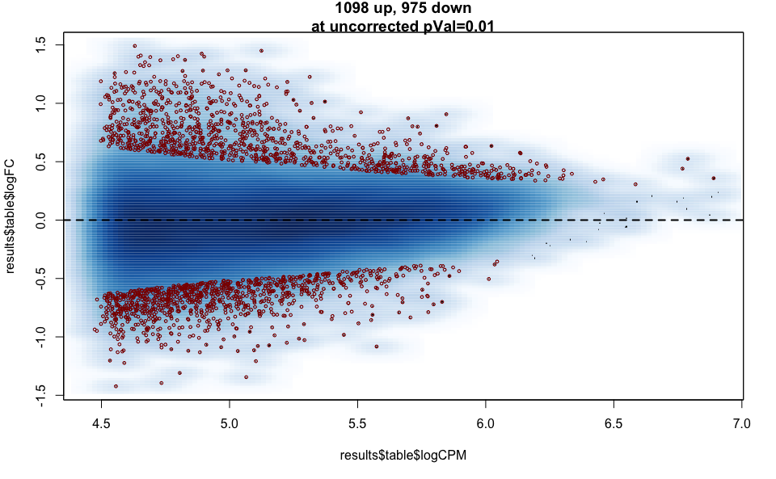

```r
points(results$table$logCPM[results$table$PValue <= window.pval.cut.off], results$table$logFC[results$table$PValue < window.pval.cut.off], col="darkred", cex=0.5)
```

```r
## Cluster overlapping and adjacent windows into clusters (if two windows are more than window apart - don't merge them). Use maximum cluster size set in the parameters file. If a cluster is larger than the maximum size, it is split into 2 equal clusters.
## Set the maximum cluster size
max.cluster.size <- 7000L
merged <- mergeWindows(rowRanges(filtered.counts), tol = 1L, max.width = max.cluster.size)
## Combine p values of the clustered windows
tabcom <- combineTests(merged$id, results$table)
## Add the "best window" info for each cluster. "Best window" is defined as the window with the smallest p value in a given cluster.
tab.best <- getBestTest(merged$id, results$table)
colnames(tab.best) <- paste0("window.", colnames(tab.best))
tabcom <- cbind(tabcom, tab.best)
## Add status
tabcom$status <- "NS"
tabcom$status[tabcom$FDR < fdr.cut.off & tabcom$window.logFC > 0] <- "Up"
tabcom$status[tabcom$FDR < fdr.cut.off & tabcom$window.logFC < 0] <- "Down"
sum.table <- rbind(
    window.level.pVal.lt.0.01 = c(
        "total.count" = nrow(results$table),
        "all.DB" = sum(results$table$PValue < window.pval.cut.off),
        "DB.Up" = sum(results$table$PValue < window.pval.cut.off  & results$table$logFC > 0),
        "DB.Down" = sum(results$table$PValue < window.pval.cut.off  & results$table$logFC < 0)),
    cluster.level.pVal.lt.0.1 = c(
        "total.count" = nrow(tabcom),
        "all.DB" = sum(tabcom$status != "NS"),
        "DB.Up" = sum(tabcom$status == "Up"),
        "DB.Down" = sum(tabcom$status == "Down")))
rownames(sum.table) <- c(paste0("window.level.pVal.lt.", window.pval.cut.off), paste0("cluster.level.FDR.lt.", fdr.cut.off))
print(sum.table)
```

```
                          total.count all.DB DB.Up DB.Down
window.level.pVal.lt.0.01       26742   2073  1098     975
cluster.level.FDR.lt.0.05        2234    255   130     125
```

So by accounting for the embryo age we have almost doubled the number of DB clusters. We still see some trend in the final MA plot. It’s not too worrying, but we could try to correct for it. This is done by fitting a loess function so that we get a matrix of count offsets at different abundance levels. These offsets are then supplied when fitting the model. We just need to remember to re-set normalisation factors to 1 so that we don’t normalise twice.

```r
## Re-set normalisation factors
x$samples$norm.factors <- 1
## Calculate trended offsets
normfacs.loess <- normOffsets(filtered.counts, type = "loess")
## Plot an MDS plot of samples taking normalisation strategy into account
par(mfrow=c(1,2))
plotMDS(cpm(x$counts - 2^(normfacs.loess/log(2)), lib.size = x$samples$lib.size, prior.count = 0.5, log = T), col = as.numeric(x$samples$group), main = "Coloured by group - trended normalisation", top = 1000)
plotMDS(cpm(x$counts - 2^(normfacs.loess/log(2)), lib.size = x$samples$lib.size, prior.count = 0.5, log = T), col = as.numeric(x$samples$batch), main = "Coloured by batch - trended normalisation", top = 1000)
```

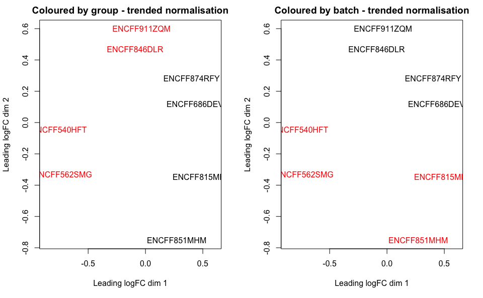

```r
## Include batch effect in the design matrix
des <- model.matrix(~ 0 + x$samples$group + x$samples$batch)
colnames(des) <- c(levels(x$samples$group), paste0("Batch", unique(x$samples$batch))[-1])
x <- estimateDisp(x, design = des)
## Fit a model including trending normalisation offset
fit <- glmQLFit(x, des, robust=TRUE, offset = normfacs.loess)
ForeVsHind <- makeContrasts(forebrain - hindbrain, levels = des)
results <- glmQLFTest(fit, contrast = ForeVsHind)
sum.table <- as.data.frame(rbind(
    window.level.pVal.lt.0.01 = c(
        "total.count" = nrow(results$table),
        "all.DB" = sum(results$table$PValue < window.pval.cut.off),
        "DB.Up" = sum(results$table$PValue < window.pval.cut.off  & results$table$logFC > 0),
        "DB.Down" = sum(results$table$PValue < window.pval.cut.off  & results$table$logFC < 0))))
## Draw the MA plot for individual windows
par(mfrow=c(1,1))
```

```r
smoothScatter(results$table$logCPM, results$table$logFC, main = paste0(sum.table$DB.Up, " up, ", sum.table$DB.Down, " down\nat uncorrected pVal=", window.pval.cut.off))
abline(h=0, lty = 2, lwd = 2)
```

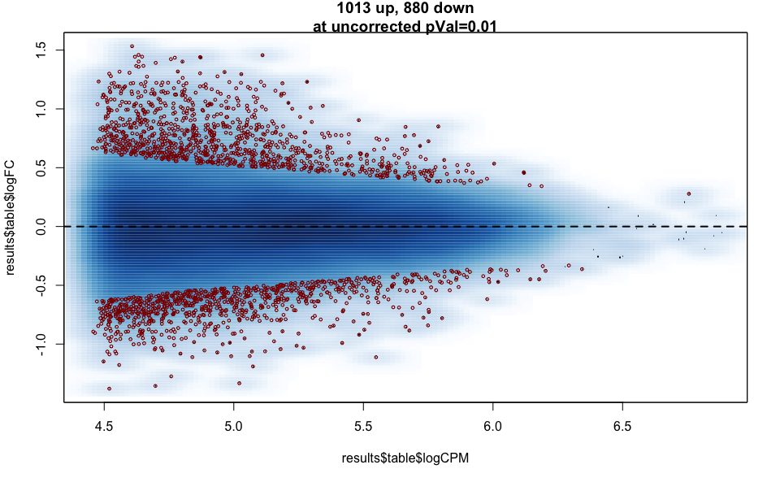

```r
points(results$table$logCPM[results$table$PValue <= window.pval.cut.off], results$table$logFC[results$table$PValue < window.pval.cut.off], col="darkred", cex=0.5)
```

```r
## Cluster overlapping and adjacent windows into clusters (if two windows are more than window apart - don't merge them). Use maximum cluster size set in the parameters file. If a cluster is larger than the maximum size, it is split into 2 equal clusters.
## Set the maximum cluster size
max.cluster.size <- 7000L
merged <- mergeWindows(rowRanges(filtered.counts), tol = 1L, max.width = max.cluster.size)
## Combine p values of the clustered windows
tabcom <- combineTests(merged$id, results$table)
## Add the "best window" info for each cluster. "Best window" is defined as the window with the smallest p value in a given cluster.
tab.best <- getBestTest(merged$id, results$table)
colnames(tab.best) <- paste0("window.", colnames(tab.best))
tabcom <- cbind(tabcom, tab.best)
## Add region coordinates to the cluster table
tabcom <- cbind(tabcom, as.data.frame(merged$region)[,-5])
## Also add the same coordinates in a single IGV compatible string
tabcom$cluster.coordinates <- paste0(tabcom$seqnames, ":", tabcom$start, "-", tabcom$end)
## Add status
tabcom$status <- "NS"
tabcom$status[tabcom$FDR < fdr.cut.off & tabcom$window.logFC > 0] <- "Up"
tabcom$status[tabcom$FDR < fdr.cut.off & tabcom$window.logFC < 0] <- "Down"
sum.table <- rbind(
    window.level.pVal.lt.0.01 = c(
        "total.count" = nrow(results$table),
        "all.DB" = sum(results$table$PValue < window.pval.cut.off),
        "DB.Up" = sum(results$table$PValue < window.pval.cut.off  & results$table$logFC > 0),
        "DB.Down" = sum(results$table$PValue < window.pval.cut.off  & results$table$logFC < 0)),
    cluster.level.pVal.lt.0.1 = c(
        "total.count" = nrow(tabcom),
        "all.DB" = sum(tabcom$status != "NS"),
        "DB.Up" = sum(tabcom$status == "Up"),
        "DB.Down" = sum(tabcom$status == "Down")))
rownames(sum.table) <- c(paste0("window.level.pVal.lt.", window.pval.cut.off), paste0("cluster.level.FDR.lt.", fdr.cut.off))
print(sum.table)
```

```
                          total.count all.DB DB.Up DB.Down
window.level.pVal.lt.0.01       26742   1893  1013     880
cluster.level.FDR.lt.0.05        2234    237   132     105
```

The trended bias could be a lot stronger than in this case, as, for example, here:

[figure not shown]

## Cluster annotation

Now that we have out “final set” of clusters, we will annotate them at 3 different level: gene body, promoter and enhancer. Promoter is defined as 3 kb up- and down-stream of TSS.We will use BioConductor TxDb.Mmusculus.UCSC.mm10.knownGene to extract gene body and TSS coordinates. Enhancer coordinates are derived using an external tool. Since p value and FDR cut-offs are somewhat arbitrary, I tend to annotate and keep all the clusters.

```r
## Generate gene body and promoter annotations
symbs <- toTable(org.Mm.egSYMBOL)
## Gene body
gene.anno <- unlist(transcriptsBy(TxDb.Mmusculus.UCSC.mm10.knownGene, by = "gene"))
strand(gene.anno) <- "*"
gene.anno$GeneID <- names(gene.anno)
gene.anno$Symbols <- symbs$symbol[match(gene.anno$GeneID, symbs$gene_id)]
gene.anno <- gene.anno[!is.na(gene.anno$Symbols)]
# head(gene.anno)
tss.anno <- promoters(TxDb.Mmusculus.UCSC.mm10.knownGene, 3000, 3000)
strand(tss.anno) <- "*"
txid <- as.character(tss.anno$tx_id)
gene_ids <- select(TxDb.Mmusculus.UCSC.mm10.knownGene, txid, "GENEID", "TXID")
tss.anno$GeneID <- gene_ids$GENEID[match(tss.anno$tx_id, gene_ids$TXID)]
tss.anno$Symbols <- symbs$symbol[match(tss.anno$GeneID, symbs$gene_id)]
tss.anno <- tss.anno[!is.na(tss.anno$Symbols)]
# head(tss.anno)
## Load enhancer annotation
enh.anno <- GRanges(read.table("./data/all_enhancers.mm10.bed", stringsAsFactors = F, col.names = c("chr", "start", "end")))
names(enh.anno) <- paste0(seqnames(enh.anno), ":", start(enh.anno), "-", end(enh.anno))
# head(enh.anno)
### Find overlaps with the gene body
olaps <- as.data.frame(findOverlaps(GRanges(tabcom[,12:14]), gene.anno, maxgap = 1000))
## For each cluster id find all genes that it overlaps and report a list of unique gene symbols
region.Symbols <- tapply(olaps$subjectHits, olaps$queryHits, function(x) paste(unique(gene.anno[x]$Symbols), collapse = "; "))
tabcom$gene.overlap <- NA
tabcom$gene.overlap[as.numeric(names(region.Symbols))] <- region.Symbols
### Find overlaps with the promoter
olaps <- as.data.frame(findOverlaps(GRanges(tabcom[,12:14]), tss.anno, maxgap = 1000))
## For each cluster id find all promoters that it overlaps and report a list of unique gene symbols
region.Symbols <- tapply(olaps$subjectHits, olaps$queryHits, function(x) paste(unique(tss.anno[x]$Symbols), collapse = "; "))
tabcom$promoter.overlap <- NA
tabcom$promoter.overlap[as.numeric(names(region.Symbols))] <- region.Symbols
### Find overlaps with enhancers
olaps <- as.data.frame(findOverlaps(GRanges(tabcom[,12:14]), enh.anno, maxgap = 1000))
## For each cluster id find all enhancers that it overlaps and report a list of enhancer ids (enhancer coordinates).
region.Symbols <- tapply(olaps$subjectHits, olaps$queryHits, function(x) paste(names(enh.anno[x]), collapse = "; "))
tabcom$enhancer.overlap <- NA
tabcom$enhancer.overlap[as.numeric(names(region.Symbols))] <- region.Symbols
write.csv(tabcom[order(tabcom$PValue),], file = "./reports/DB.results.table.csv")
write.csv(sum.table, file = "./reports/DB.results.summary.csv")
```

Let’s have a look at the results table.

```r
print(head(tabcom[order(tabcom$PValue),], 20))
```

|  | nWindows | logFC.up | logFC.down | PValue | FDR | window.best | window.logFC | window.logCPM | window.F | window.PValue | window.FDR | seqnames | start | end | width | cluster.coordinates | status | gene.overlap | promoter.overlap | enhancer.overlap |
| --- | --- | --- | --- | --- | --- | --- | --- | --- | --- | --- | --- | --- | --- | --- | --- | --- | --- | --- | --- | --- |
| 1249 | 10 | 10 | 0 | 6.538087e-12 | 1.460609e-08 | 15925 | 1.456529 | 5.110773 | 51.68850 | 6.538087e-12 | 1.460609e-08 | chr19 | 37421851 | 37423500 | 1650 | chr19:37421851-37423500 | Up | Kif11 | NA | NA |
| 1226 | 4 | 4 | 0 | 1.277562e-10 | 1.427037e-07 | 15785 | 1.437375 | 4.871988 | 44.06173 | 1.277562e-10 | 1.427037e-07 | chr19 | 37384951 | 37385700 | 750 | chr19:37384951-37385700 | Up | Kif11 | NA | NA |
| 1245 | 7 | 7 | 0 | 4.626118e-10 | 3.156559e-07 | 15909 | 1.230364 | 5.282591 | 42.63843 | 4.626118e-10 | 3.156559e-07 | chr19 | 37416001 | 37417200 | 1200 | chr19:37416001-37417200 | Up | Kif11 | NA | NA |
| 1838 | 26 | 0 | 24 | 6.270405e-10 | 3.156559e-07 | 22892 | -1.111625 | 5.548643 | 44.61184 | 6.270405e-10 | 3.156559e-07 | chr19 | 47023201 | 47027250 | 4050 | chr19:47023201-47027250 | Down | Ina | NA | NA |
| 1233 | 4 | 4 | 0 | 7.064813e-10 | 3.156559e-07 | 15817 | 1.435522 | 4.772397 | 40.71592 | 7.064813e-10 | 3.156559e-07 | chr19 | 37393801 | 37394550 | 750 | chr19:37393801-37394550 | Up | Kif11 | NA | NA |
| 1246 | 3 | 3 | 0 | 9.148185e-10 | 3.406174e-07 | 15913 | 1.423221 | 4.757353 | 39.64874 | 9.148185e-10 | 3.406174e-07 | chr19 | 37417651 | 37418250 | 600 | chr19:37417651-37418250 | Up | Kif11 | NA | NA |
| 1522 | 9 | 0 | 9 | 1.339307e-09 | 4.274304e-07 | 18602 | -1.333009 | 5.021201 | 41.05083 | 1.339307e-09 | 4.274304e-07 | chr19 | 42266401 | 42267900 | 1500 | chr19:42266401-42267900 | Down | Golga7b | NA | NA |
| 2141 | 2 | 2 | 0 | 2.551752e-09 | 7.125767e-07 | 26091 | 1.444007 | 4.646356 | 36.85504 | 2.551752e-09 | 7.125767e-07 | chr19 | 59428351 | 59428800 | 450 | chr19:59428351-59428800 | Up | Emx2os | NA | NA |
| 1229 | 2 | 2 | 0 | 4.056027e-09 | 9.438731e-07 | 15796 | 1.391584 | 4.698698 | 35.95155 | 4.056027e-09 | 9.438731e-07 | chr19 | 37389001 | 37389450 | 450 | chr19:37389001-37389450 | Up | Kif11 | NA | NA |
| 1261 | 16 | 13 | 0 | 4.682133e-09 | 9.438731e-07 | 15975 | 1.295626 | 5.028769 | 39.72922 | 4.682133e-09 | 9.438731e-07 | chr19 | 38059201 | 38061750 | 2550 | chr19:38059201-38061750 | Up | Cep55 | NA | NA |

[output cut: 10 more lines]

Finally, let’s save two bed files, one for all the filtered windows and the other for the clustered windows. We will encode the p value for each window and each cluster as a bed-compatible colour score.

```r
## Write a bed file for all windows with a p value as a score (-log10)
window.bed.file <- data.frame(chr = as.character(seqnames(rowRanges(filtered.counts))),
                              start = start(rowRanges(filtered.counts)),
                              end = end(rowRanges(filtered.counts)),
                              log10.Pvalue = -log10(results$table$PValue),
                              score = round(-log10(results$table$PValue), digits = 2)*100,
                              stringsAsFactors = F)
window.bed.file <- rbind(c("track color=0,60,120 useScore=1 db=mm10", "NA", "NA", "NA", "NA"), window.bed.file)
write.table(window.bed.file, file = "./reports/window.level.db.results.bed", quote = F, sep = "\t", row.names = F, col.names = F)
## Write a bed file for all clusters with a p value as a score (-log10)
cluster.bed.file <- data.frame(chr = as.character(tabcom$seqnames),
                               start = tabcom$start,
                               end = tabcom$end,
                               log10.Pvalue = -log10(tabcom$PValue),
                               score = round(-log10(tabcom$PValue), digits = 2)*100,
                               stringsAsFactors = F)
cluster.bed.file <- rbind(c("track color=0,60,120 useScore=1 db=mm10", "NA", "NA", "NA", "NA"), cluster.bed.file)
write.table(cluster.bed.file, file = "./reports/cluster.level.db.results.bed", quote = F, sep = "\t", row.names = F, col.names = F, na = "")
```